# Meta-Analyses in Education: From Theory to Practice with R

# Moderator analyses

## Moderation by the availability of IPD

```r
## Mixed-effects meta-regression model
REM.ipd <- rma.mv(g,
                    Var.g,
                    random = list(~ 1 | ESID),
                    method = "REML",
                    data = dat,
                    tdist = TRUE,
                    test = "t",
                    mods =~ IPD)

# Summarize the results
summary(REM.ipd, digits=4)
```

```
##
## Multivariate Meta-Analysis Model (k = 59; method: REML)
##
##   logLik  Deviance       AIC       BIC      AICc
##  26.4207  -52.8414  -46.8414  -40.7122  -46.3886
##
## Variance Components:
##
##             estim    sqrt  nlvls  fixed  factor
## sigma^2    0.0153  0.1236     59     no    ESID
##
## Test for Residual Heterogeneity:
## QE(df = 57) = 578.8574, p-val < .0001
##
## Test of Moderators (coefficient 2):
## F(df1 = 1, df2 = 57) = 1.5286, p-val = 0.2214
##
## Model Results:
##
##          estimate      se    tval  df    pval    ci.lb   ci.ub
## intrcpt    0.1170  0.0291  4.0192  57  0.0002   0.0587  0.1752  ***
## IPD        0.0452  0.0366  1.2364  57  0.2214  -0.0280  0.1185
##
## ---
## Signif. codes:  0 '***' 0.001 '**' 0.01 '*' 0.05 '.' 0.1 ' ' 1
```

```r
## Cluster-robust standard errors
robust(REM.ipd, cluster = IDSTUDY, clubSandwich = FALSE)
```

```
##
## Multivariate Meta-Analysis Model (k = 59; method: REML)
##
## Variance Components:
##
##             estim    sqrt  nlvls  fixed  factor
## sigma^2    0.0153  0.1236     59     no    ESID
##
## Test for Residual Heterogeneity:
## QE(df = 57) = 578.8574, p-val < .0001
##
## Number of estimates:   59
## Number of clusters:    24
## Estimates per cluster: 1-21 (mean: 2.46, median: 1)
##
## Test of Moderators (coefficient 2):¹
## F(df1 = 1, df2 = 22) = 0.9164, p-val = 0.3488
##
## Model Results:
##
##          estimate      se¹    tval¹  df¹    pval¹    ci.lb¹   ci.ub¹
## intrcpt    0.1170  0.0383   3.0533   22   0.0058    0.0375   0.1964   **
## IPD        0.0452  0.0472   0.9573   22   0.3488   -0.0527   0.1432
##
## ---
## Signif. codes:  0 '***' 0.001 '**' 0.01 '*' 0.05 '.' 0.1 ' ' 1
##
## 1) results based on cluster-robust inference (var-cov estimator: CR1,
##    approx t/F-tests and confidence intervals, df: residual method)
```

```r
robust(REM.ipd, cluster = IDCOUNTRY, clubSandwich = FALSE)
```

```
##
## Multivariate Meta-Analysis Model (k = 59; method: REML)
##
## Variance Components:
##
##             estim    sqrt  nlvls  fixed  factor
## sigma^2    0.0153  0.1236     59     no    ESID
##
## Test for Residual Heterogeneity:
## QE(df = 57) = 578.8574, p-val < .0001
##
## Number of estimates:   59
## Number of clusters:    31
## Estimates per cluster: 1-7 (mean: 1.90, median: 1)
##
## Test of Moderators (coefficient 2):¹
## F(df1 = 1, df2 = 29) = 1.6652, p-val = 0.2071
##
## Model Results:
##
##          estimate      se¹    tval¹  df¹    pval¹    ci.lb¹   ci.ub¹
## intrcpt    0.1170  0.0322   3.6350   29   0.0011    0.0512   0.1828   **
## IPD        0.0452  0.0350   1.2904   29   0.2071   -0.0265   0.1169
##
## ---
## Signif. codes:  0 '***' 0.001 '**' 0.01 '*' 0.05 '.' 0.1 ' ' 1
##
## 1) results based on cluster-robust inference (var-cov estimator: CR1,
##    approx t/F-tests and confidence intervals, df: residual method)
```

```r
## Model specification to get the group-specific effect sizes
REM.ipd2 <- rma.mv(g,
                    Var.g,
                    random = list(~ 1 | ESID),
                    method = "REML",
                    data = dat,
                    tdist = TRUE,
                    test = "t",
                    mods =~ factor(IPD) - 1 # remove the intercept
                    )

# Summarize the results
summary(REM.ipd2, digits=4)
```

```
##
## Multivariate Meta-Analysis Model (k = 59; method: REML)
##
##   logLik  Deviance       AIC       BIC      AICc
##  26.4207  -52.8414  -46.8414  -40.7122  -46.3886
##
## Variance Components:
##
##             estim    sqrt  nlvls  fixed  factor
## sigma^2    0.0153  0.1236     59     no    ESID
##
## Test for Residual Heterogeneity:
## QE(df = 57) = 578.8574, p-val < .0001
##
## Test of Moderators (coefficients 1:2):
## F(df1 = 2, df2 = 57) = 34.8521, p-val < .0001
##
## Model Results:
##
##               estimate      se    tval  df    pval   ci.lb   ci.ub
## factor(IPD)0    0.1170  0.0291  4.0192  57  0.0002  0.0587  0.1752  ***
## factor(IPD)1    0.1622  0.0222  7.3178  57  <.0001  0.1178  0.2066  ***
##
## ---
## Signif. codes:  0 '***' 0.001 '**' 0.01 '*' 0.05 '.' 0.1 ' ' 1
```

No evidence on significant differences in the effect sizes between studies providing IPD and studies providing only aggregated data.

## Moderation by Publication Year

```r
## Mixed-effects meta-regression model
REM.py <- rma.mv(g,
                    Var.g,
                    random = list(~ 1 | ESID),
                    method = "REML",
                    data = dat,
                    tdist = TRUE,
                    test = "t",
                    mods =~ scale(PubYear, ## standardized
                            center = TRUE,
                            scale = TRUE))

# Summarize the results
summary(REM.py, digits=4)
```

```
##
## Multivariate Meta-Analysis Model (k = 59; method: REML)
##
##   logLik  Deviance       AIC       BIC      AICc
##  31.3326  -62.6651  -56.6651  -50.5360  -56.2123
##
## Variance Components:
##
##             estim    sqrt  nlvls  fixed  factor
## sigma^2    0.0123  0.1108     59     no    ESID
##
## Test for Residual Heterogeneity:
## QE(df = 57) = 470.8095, p-val < .0001
##
## Test of Moderators (coefficient 2):
## F(df1 = 1, df2 = 57) = 12.6320, p-val = 0.0008
##
## Model Results:
##
##                                              estimate      se    tval  df
## intrcpt                                        0.1426  0.0161  8.8846  57
## scale(PubYear, center = TRUE, scale = TRUE)    0.0566  0.0159  3.5541  57
##                                                pval   ci.lb   ci.ub
## intrcpt                                      <.0001  0.1105  0.1748  ***
## scale(PubYear, center = TRUE, scale = TRUE)  0.0008  0.0247  0.0885  ***
##
## ---
## Signif. codes:  0 '***' 0.001 '**' 0.01 '*' 0.05 '.' 0.1 ' ' 1
```

```r
## Cluster-robust standard errors
robust(REM.py,  cluster = IDSTUDY, clubSandwich = FALSE)
```

```
##
## Multivariate Meta-Analysis Model (k = 59; method: REML)
##
## Variance Components:
##
##             estim    sqrt  nlvls  fixed  factor
## sigma^2    0.0123  0.1108     59     no    ESID
##
## Test for Residual Heterogeneity:
## QE(df = 57) = 470.8095, p-val < .0001
##
## Number of estimates:   59
## Number of clusters:    24
## Estimates per cluster: 1-21 (mean: 2.46, median: 1)
##
## Test of Moderators (coefficient 2):¹
## F(df1 = 1, df2 = 22) = 14.0232, p-val = 0.0011
##
## Model Results:
##
##                                              estimate      se¹     tval¹  df¹
## intrcpt                                        0.1426  0.0139   10.2805   22
## scale(PubYear, center = TRUE, scale = TRUE)    0.0566  0.0151    3.7448   22
##                                                pval¹   ci.lb¹   ci.ub¹
## intrcpt                                      <.0001   0.1139   0.1714   ***
## scale(PubYear, center = TRUE, scale = TRUE)  0.0011   0.0253   0.0880    **
##
## ---
## Signif. codes:  0 '***' 0.001 '**' 0.01 '*' 0.05 '.' 0.1 ' ' 1
##
## 1) results based on cluster-robust inference (var-cov estimator: CR1,
##    approx t/F-tests and confidence intervals, df: residual method)
```

```r
## Variance explanation
## Level-specific R-squared as the proportional variance reduction

## Level: Primary studies
max(1-REM.py$sigma2[1]/REM$sigma2[1] , 0)
```

```
## [1] 0.2111067
```

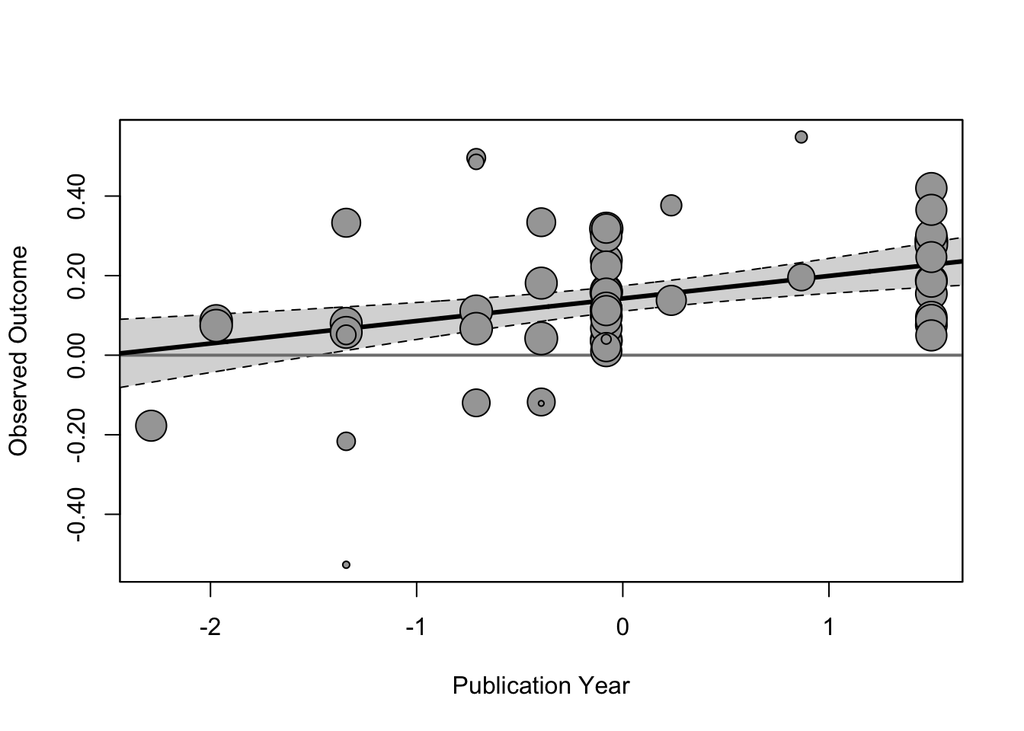

```r
## Regression plot
regplot(REM.py,
        xlab = "Publication Year",
        refline = 0,
        digits = 2)
```

```r
## RVE Model with hierarchical effects and Publication Yeaer
RVE.count.py <- robu(g ~ 1 + scale(PubYear, center = TRUE, scale = TRUE),
                  data = dat,
                  studynum = IDCOUNTRY,
                  var.eff.size = Var.g,
                  small = FALSE,
                  modelweights = "HIER")
# Summarize the results
print(RVE.count.py, digits=4)
```

```
## RVE: Hierarchical Effects Model
##
## Model: g ~ 1 + scale(PubYear, center = TRUE, scale = TRUE)
##
## Number of clusters = 31
## Number of outcomes = 59 (min = 1 , mean = 1.9 , median = 1 , max = 7 )
## Omega.sq = 0.00992801
## Tau.sq = 0.0003710178
##
##                                               Estimate  StdErr t-value dfs
## 1                                X.Intercept.  0.14247 0.01647   8.652  29
## 2 scale.PubYear..center...TRUE..scale...TRUE.  0.05608 0.01626   3.450  29
##          P(|t|>) 95% CI.L 95% CI.U Sig
## 1 0.000000001583  0.10879  0.17615 ***
## 2 0.001736958944  0.02284  0.08933 ***
## ---
## Signif. codes: < .01 *** < .05 ** < .10 *
## ---
```

Publication year explains about 21.1$\%$ of the between-study heterogeneity in the effect sizes. Studies published more recently tended to report larger effect sizes.

## Moderation by Power Distance Index and Gross Domestic Product

```r
## Mixed-effects meta-regression model
REM.pgd <- rma.mv(g,
                    Var.g,
                    random = list(~ 1 | ESID),
                    method = "REML",
                    data = dat,
                    tdist = TRUE,
                    test = "t",
                    mods =~ scale(PDI, ## standardized
                                  center = TRUE,
                                  scale = TRUE) +
                      scale(cGDP, ## standardized
                            center = TRUE,
                            scale = TRUE))

# Summarize the results
summary(REM.pgd, digits=4)
```

```
##
## Multivariate Meta-Analysis Model (k = 59; method: REML)
##
##   logLik  Deviance       AIC       BIC      AICc
##  25.6126  -51.2251  -43.2251  -35.1237  -42.4408
##
## Variance Components:
##
##             estim    sqrt  nlvls  fixed  factor
## sigma^2    0.0159  0.1261     59     no    ESID
##
## Test for Residual Heterogeneity:
## QE(df = 56) = 589.6128, p-val < .0001
##
## Test of Moderators (coefficients 2:3):
## F(df1 = 2, df2 = 56) = 1.0476, p-val = 0.3576
##
## Model Results:
##
##                                           estimate      se    tval  df    pval
## intrcpt                                     0.1453  0.0179  8.0962  56  <.0001
## scale(PDI, center = TRUE, scale = TRUE)     0.0164  0.0267  0.6132  56  0.5422
## scale(cGDP, center = TRUE, scale = TRUE)    0.0358  0.0269  1.3314  56  0.1884
##                                             ci.lb   ci.ub
## intrcpt                                    0.1093  0.1812  ***
## scale(PDI, center = TRUE, scale = TRUE)   -0.0371  0.0698
## scale(cGDP, center = TRUE, scale = TRUE)  -0.0180  0.0896
##
## ---
## Signif. codes:  0 '***' 0.001 '**' 0.01 '*' 0.05 '.' 0.1 ' ' 1
```

```r
## Cluster-robust standard errors
robust(REM.pgd, cluster = IDSTUDY, clubSandwich = FALSE)
```

```
##
## Multivariate Meta-Analysis Model (k = 59; method: REML)
##
## Variance Components:
##
##             estim    sqrt  nlvls  fixed  factor
## sigma^2    0.0159  0.1261     59     no    ESID
##
## Test for Residual Heterogeneity:
## QE(df = 56) = 589.6128, p-val < .0001
##
## Number of estimates:   59
## Number of clusters:    24
## Estimates per cluster: 1-21 (mean: 2.46, median: 1)
##
## Test of Moderators (coefficients 2:3):¹
## F(df1 = 2, df2 = 21) = 3.8362, p-val = 0.0380
##
## Model Results:
##
##                                           estimate      se¹    tval¹  df¹
## intrcpt                                     0.1453  0.0234   6.2089   21
## scale(PDI, center = TRUE, scale = TRUE)     0.0164  0.0213   0.7681   21
## scale(cGDP, center = TRUE, scale = TRUE)    0.0358  0.0152   2.3495   21
##                                             pval¹    ci.lb¹   ci.ub¹
## intrcpt                                   <.0001    0.0966   0.1939   ***
## scale(PDI, center = TRUE, scale = TRUE)   0.4510   -0.0279   0.0606
## scale(cGDP, center = TRUE, scale = TRUE)  0.0287    0.0041   0.0674     *
##
## ---
## Signif. codes:  0 '***' 0.001 '**' 0.01 '*' 0.05 '.' 0.1 ' ' 1
##
## 1) results based on cluster-robust inference (var-cov estimator: CR1,
##    approx t/F-tests and confidence intervals, df: residual method)
```

```r
robust(REM.pgd, cluster = IDCOUNTRY, clubSandwich = FALSE)
```

```
##
## Multivariate Meta-Analysis Model (k = 59; method: REML)
##
## Variance Components:
##
##             estim    sqrt  nlvls  fixed  factor
## sigma^2    0.0159  0.1261     59     no    ESID
##
## Test for Residual Heterogeneity:
## QE(df = 56) = 589.6128, p-val < .0001
##
## Number of estimates:   59
## Number of clusters:    31
## Estimates per cluster: 1-7 (mean: 1.90, median: 1)
##
## Test of Moderators (coefficients 2:3):¹
## F(df1 = 2, df2 = 28) = 3.3521, p-val = 0.0495
##
## Model Results:
##
##                                           estimate      se¹    tval¹  df¹
## intrcpt                                     0.1453  0.0191   7.6182   28
## scale(PDI, center = TRUE, scale = TRUE)     0.0164  0.0189   0.8639   28
## scale(cGDP, center = TRUE, scale = TRUE)    0.0358  0.0151   2.3672   28
##                                             pval¹    ci.lb¹   ci.ub¹
## intrcpt                                   <.0001    0.1062   0.1843   ***
## scale(PDI, center = TRUE, scale = TRUE)   0.3950   -0.0224   0.0551
## scale(cGDP, center = TRUE, scale = TRUE)  0.0251    0.0048   0.0667     *
##
## ---
## Signif. codes:  0 '***' 0.001 '**' 0.01 '*' 0.05 '.' 0.1 ' ' 1
##
## 1) results based on cluster-robust inference (var-cov estimator: CR1,
##    approx t/F-tests and confidence intervals, df: residual method)
```

```r
## Check for non-essential multicollinearity
## Note: Values below 10 could be considered acceptable.
## Source: Kim (2019), https://doi.org/10.4097/kja.19087
vif.rma(REM.pgd)
```

```
##
## scale(PDI, center = TRUE, scale = TRUE)  scale(cGDP, center = TRUE, scale = TRUE)
##                                  2.2476                                    2.2476
```

```r
## Variance explanation
## Level-specific R-squared as the proportional variance reduction

## Level: Primary studies
max(1-REM.pgd$sigma2[1]/REM$sigma2[1] , 0)
```

```
## [1] 0
```

About 0$\%$ of the between-study heterogeneity in the effect sizes are explained by the PDI and GDP.

# Publication Bias and Influential Effect Sizes

Given that the data set contains both AD and IPD data, publication (aka selection) bias may exist. We take several approaches to check for this kind of bias. Moreover, some effect sizes may be influential and drive the overall effect size estimate. Hence, we also identify influential effect sizes.

## Egger’s regression test and funnel plot

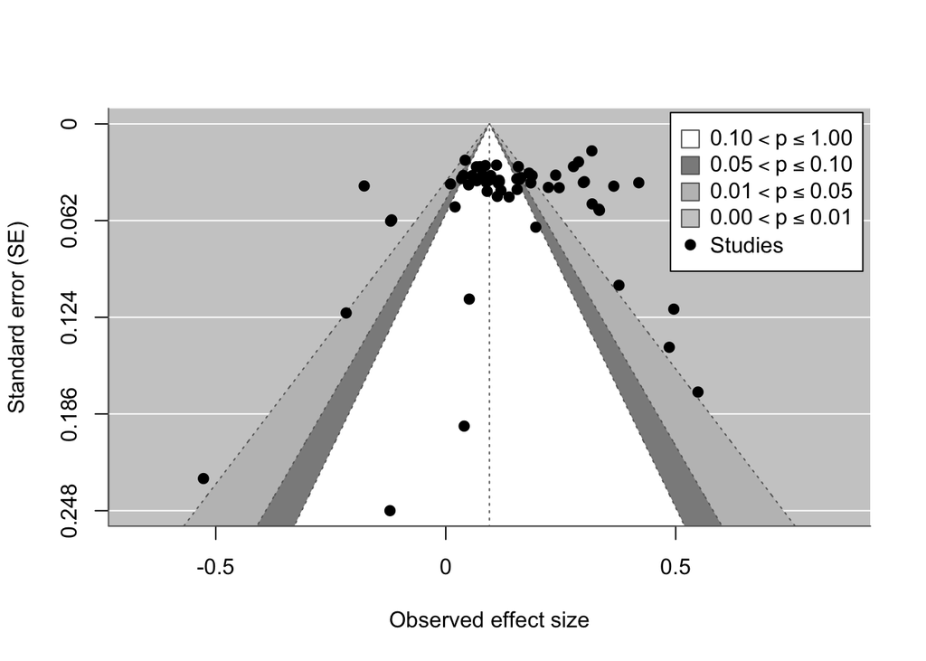

```r
## Contour-enhanced funnel plot
## Source: https://www.metafor-project.org/doku.php/plots:funnel_plot_variations
## https://www.metafor-project.org/doku.php/plots:contour_enhanced_funnel_plot
metafor::funnel(CCREM,
                yaxis = "sei",
                level = c(90, 95, 99),
                shade = c("white", "gray55", "gray75"),
                legend = TRUE,
                xlab = "Observed effect size",
                ylab = "Standard error (SE)")
```

```r
## Source: https://bookdown.org/MathiasHarrer/Doing_Meta_Analysis_in_R/pub-bias.html#addressing-pubbias

## Original Egger's Test
## Note: g/sqrt(Var.g) represents the z-score of the effect size.
## 1/sqrt(Var.g) represents the precision of the effect size.
dat %>%
  mutate(y = g/sqrt(Var.g), x = 1/sqrt(Var.g)) %>%
  lm(y ~ x, data = .) %>%
  summary()
```

```
##
## Call:
## lm(formula = y ~ x, data = .)
##
## Residuals:
##    Min     1Q Median     3Q    Max
## -8.167 -2.273 -0.220  2.496  8.462
##
## Coefficients:
##             Estimate Std. Error t value Pr(>|t|)
## (Intercept) -1.02987    1.08467  -0.949    0.346
## x            0.18896    0.04042   4.675 1.85e-05 ***
## ---
## Signif. codes:  0 '***' 0.001 '**' 0.01 '*' 0.05 '.' 0.1 ' ' 1
##
## Residual standard error: 3.199 on 57 degrees of freedom
## Multiple R-squared:  0.2771, Adjusted R-squared:  0.2644
## F-statistic: 21.85 on 1 and 57 DF,  p-value: 1.847e-05
```

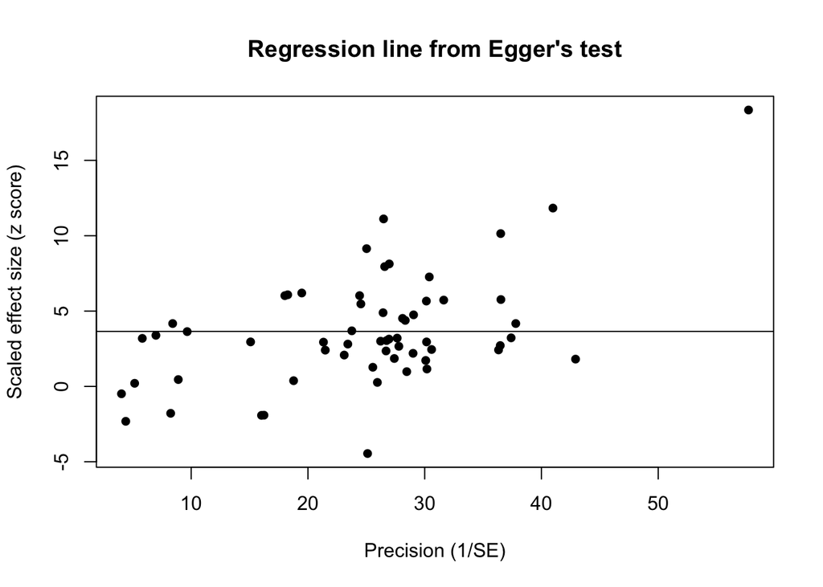

```r
## Graphical illustration
plot(x = 1/sqrt(dat$Var.g),
     y = dat$g/sqrt(dat$Var.g),
     main = "Regression line from Egger's test",
     xlab = "Precision (1/SE)",
     ylab = "Scaled effect size (z score)",
     pch = 16)
abline(lm(dat$g/sqrt(dat$Var.g) ~ 1/sqrt(dat$Var.g)))
```

```r
## Modified version of this test
## Source: Pustejovsky & Rodgers (2019), https://doi.org/10.1002/jrsm.1332
## Note: For standardized mean differences, the effects and their standard errors are dependent.
## Hence, the use of the modified standard errors.
dat$SEg_modified <- sqrt((dat$nF + dat$nM)/(dat$nF*dat$nM))

dat %>%
  mutate(y = g/SEg_modified, x = 1/SEg_modified) %>%
  lm(y ~ x, data = .) %>%
  summary()
```

```
##
## Call:
## lm(formula = y ~ x, data = .)
##
## Residuals:
##     Min      1Q  Median      3Q     Max
## -8.2303 -2.2775 -0.2038  2.4599  7.8082
##
## Coefficients:
##             Estimate Std. Error t value Pr(>|t|)
## (Intercept)  -1.1390     1.0976  -1.038    0.304
## x             0.1945     0.0414   4.698  1.7e-05 ***
## ---
## Signif. codes:  0 '***' 0.001 '**' 0.01 '*' 0.05 '.' 0.1 ' ' 1
##
## Residual standard error: 3.149 on 57 degrees of freedom
## Multiple R-squared:  0.2791, Adjusted R-squared:  0.2665
## F-statistic: 22.07 on 1 and 57 DF,  p-value: 1.701e-05
```

The intercepts in these tests are negative and statistically insignificant (when testing them against zero). This suggests that the funnel plot is, to a large extent, symmetrical. Hence, small-study effects may not affect the meta-analytic findings.

## Precision-Effect Test (PET)

```r
## Details: https://wviechtb.github.io/metafor/reference/regtest.html
## Multilevel MEM
CCREM.pet <- rma.mv(g,
                    Var.g,
                    random = list(~ 1 | IDSTUDY/ESID,
                                  ~ 1 | IDCOUNTRY),
                    method = "REML",
                    data = dat,
                    tdist = TRUE,
                    test = "t",
                    mods =~ sqrt(Var.g))

# Summarize the results
summary(CCREM.pet, digits=4)
```

```
##
## Multivariate Meta-Analysis Model (k = 59; method: REML)
##
##   logLik  Deviance       AIC       BIC      AICc
##  33.4927  -66.9854  -56.9854  -46.7702  -55.8090
##
## Variance Components:
##
##             estim    sqrt  nlvls  fixed        factor
## sigma^2.1  0.0330  0.1816     24     no       IDSTUDY
## sigma^2.2  0.0016  0.0401     59     no  IDSTUDY/ESID
## sigma^2.3  0.0055  0.0740     31     no     IDCOUNTRY
##
## Test for Residual Heterogeneity:
## QE(df = 57) = 583.2291, p-val < .0001
##
## Test of Moderators (coefficient 2):
## F(df1 = 1, df2 = 57) = 0.0872, p-val = 0.7688
##
## Model Results:
##
##              estimate      se     tval  df    pval    ci.lb   ci.ub
## intrcpt        0.1111  0.0706   1.5732  57  0.1212  -0.0303  0.2525
## sqrt(Var.g)   -0.2225  0.7534  -0.2953  57  0.7688  -1.7312  1.2862
##
## ---
## Signif. codes:  0 '***' 0.001 '**' 0.01 '*' 0.05 '.' 0.1 ' ' 1
```

```r
## Cluster-robust standard errors
robust(CCREM.pet, cluster = IDSTUDY, clubSandwich = FALSE)
```

```
##
## Multivariate Meta-Analysis Model (k = 59; method: REML)
##
## Variance Components:
##
##             estim    sqrt  nlvls  fixed        factor
## sigma^2.1  0.0330  0.1816     24     no       IDSTUDY
## sigma^2.2  0.0016  0.0401     59     no  IDSTUDY/ESID
## sigma^2.3  0.0055  0.0740     31     no     IDCOUNTRY
##
## Test for Residual Heterogeneity:
## QE(df = 57) = 583.2291, p-val < .0001
##
## Number of estimates:   59
## Number of clusters:    24
## Estimates per cluster: 1-21 (mean: 2.46, median: 1)
##
## Test of Moderators (coefficient 2):¹
## F(df1 = 1, df2 = 22) = 0.0501, p-val = 0.8249
##
## Model Results:
##
##              estimate      se¹     tval¹  df¹    pval¹    ci.lb¹   ci.ub¹
## intrcpt        0.1111  0.0721    1.5407   22   0.1376   -0.0384   0.2606
## sqrt(Var.g)   -0.2225  0.9939   -0.2239   22   0.8249   -2.2838   1.8388
##
## ---
## Signif. codes:  0 '***' 0.001 '**' 0.01 '*' 0.05 '.' 0.1 ' ' 1
##
## 1) results based on cluster-robust inference (var-cov estimator: CR1,
##    approx t/F-tests and confidence intervals, df: residual method)
```

```r
robust(CCREM.pet, cluster = IDCOUNTRY, clubSandwich = FALSE)
```

```
##
## Multivariate Meta-Analysis Model (k = 59; method: REML)
##
## Variance Components:
##
##             estim    sqrt  nlvls  fixed        factor
## sigma^2.1  0.0330  0.1816     24     no       IDSTUDY
## sigma^2.2  0.0016  0.0401     59     no  IDSTUDY/ESID
## sigma^2.3  0.0055  0.0740     31     no     IDCOUNTRY
##
## Test for Residual Heterogeneity:
## QE(df = 57) = 583.2291, p-val < .0001
##
## Number of estimates:   59
## Number of clusters:    31
## Estimates per cluster: 1-7 (mean: 1.90, median: 1)
##
## Test of Moderators (coefficient 2):¹
## F(df1 = 1, df2 = 29) = 0.0361, p-val = 0.8505
##
## Model Results:
##
##              estimate      se¹     tval¹  df¹    pval¹    ci.lb¹   ci.ub¹
## intrcpt        0.1111  0.0754    1.4742   29   0.1512   -0.0430   0.2652
## sqrt(Var.g)   -0.2225  1.1704   -0.1901   29   0.8505   -2.6162   2.1712
##
## ---
## Signif. codes:  0 '***' 0.001 '**' 0.01 '*' 0.05 '.' 0.1 ' ' 1
##
## 1) results based on cluster-robust inference (var-cov estimator: CR1,
##    approx t/F-tests and confidence intervals, df: residual method)
```

No evidence of publication bias due to the insignificant relation between the effect sizes and the sampling errors.

## Precision-Effect Estimate with SE (PEESE)

```r
## Multilevel MEM
CCREM.peese <- rma.mv(g,
                      Var.g,
                      random = list(~ 1 | IDSTUDY/ESID,
                                    ~ 1 | IDCOUNTRY),
                      method = "REML",
                      data = dat,
                      tdist = TRUE,
                      test = "t",
                      mods =~ Var.g)

## Summarize the results
summary(CCREM.peese, digits=4)
```

```
##
## Multivariate Meta-Analysis Model (k = 59; method: REML)
##
##   logLik  Deviance       AIC       BIC      AICc
##  33.8299  -67.6599  -57.6599  -47.4446  -56.4834
##
## Variance Components:
##
##             estim    sqrt  nlvls  fixed        factor
## sigma^2.1  0.0329  0.1814     24     no       IDSTUDY
## sigma^2.2  0.0016  0.0401     59     no  IDSTUDY/ESID
## sigma^2.3  0.0055  0.0739     31     no     IDCOUNTRY
##
## Test for Residual Heterogeneity:
## QE(df = 57) = 589.7801, p-val < .0001
##
## Test of Moderators (coefficient 2):
## F(df1 = 1, df2 = 57) = 0.6443, p-val = 0.4255
##
## Model Results:
##
##          estimate      se     tval  df    pval    ci.lb   ci.ub
## intrcpt    0.1167  0.0528   2.2119  57  0.0310   0.0110  0.2223  *
## Var.g     -2.6613  3.3155  -0.8027  57  0.4255  -9.3006  3.9779
##
## ---
## Signif. codes:  0 '***' 0.001 '**' 0.01 '*' 0.05 '.' 0.1 ' ' 1
```

```r
## Cluster-robust standard errors
robust(CCREM.peese, cluster = IDSTUDY, clubSandwich = FALSE)
```

```
##
## Multivariate Meta-Analysis Model (k = 59; method: REML)
##
## Variance Components:
##
##             estim    sqrt  nlvls  fixed        factor
## sigma^2.1  0.0329  0.1814     24     no       IDSTUDY
## sigma^2.2  0.0016  0.0401     59     no  IDSTUDY/ESID
## sigma^2.3  0.0055  0.0739     31     no     IDCOUNTRY
##
## Test for Residual Heterogeneity:
## QE(df = 57) = 589.7801, p-val < .0001
##
## Number of estimates:   59
## Number of clusters:    24
## Estimates per cluster: 1-21 (mean: 2.46, median: 1)
##
## Test of Moderators (coefficient 2):¹
## F(df1 = 1, df2 = 22) = 0.4371, p-val = 0.5154
##
## Model Results:
##
##          estimate      se¹     tval¹  df¹    pval¹     ci.lb¹   ci.ub¹
## intrcpt    0.1167  0.0505    2.3103   22   0.0306     0.0119   0.2214   *
## Var.g     -2.6613  4.0253   -0.6612   22   0.5154   -11.0092   5.6866
##
## ---
## Signif. codes:  0 '***' 0.001 '**' 0.01 '*' 0.05 '.' 0.1 ' ' 1
##
## 1) results based on cluster-robust inference (var-cov estimator: CR1,
##    approx t/F-tests and confidence intervals, df: residual method)
```

```r
robust(CCREM.peese, cluster = IDCOUNTRY, clubSandwich = FALSE)
```

```
##
## Multivariate Meta-Analysis Model (k = 59; method: REML)
##
## Variance Components:
##
##             estim    sqrt  nlvls  fixed        factor
## sigma^2.1  0.0329  0.1814     24     no       IDSTUDY
## sigma^2.2  0.0016  0.0401     59     no  IDSTUDY/ESID
## sigma^2.3  0.0055  0.0739     31     no     IDCOUNTRY
##
## Test for Residual Heterogeneity:
## QE(df = 57) = 589.7801, p-val < .0001
##
## Number of estimates:   59
## Number of clusters:    31
## Estimates per cluster: 1-7 (mean: 1.90, median: 1)
##
## Test of Moderators (coefficient 2):¹
## F(df1 = 1, df2 = 29) = 0.2914, p-val = 0.5934
##
## Model Results:
##
##          estimate      se¹     tval¹  df¹    pval¹     ci.lb¹   ci.ub¹
## intrcpt    0.1167  0.0418    2.7890   29   0.0092     0.0311   0.2023   **
## Var.g     -2.6613  4.9298   -0.5399   29   0.5934   -12.7438   7.4211
##
## ---
## Signif. codes:  0 '***' 0.001 '**' 0.01 '*' 0.05 '.' 0.1 ' ' 1
##
## 1) results based on cluster-robust inference (var-cov estimator: CR1,
##    approx t/F-tests and confidence intervals, df: residual method)
```

No evidence of publication bias due to the insignificant relation between the effect sizes and the sampling variances.

## Begg’s Correlation Test (BCT)

```r
## Source code: Fernandez-Castilla et al. (2021)
## https://doi.org/10.1080/00220973.2019.1582470

## Define the precision
preci <- 1/dat$Var.g
Stand_Var <- dat$Var.g - (1/(sum(preci)))

## Draw from the model REM3Lc
## Define the pooled effect size from a baseline model
pooled_es <- CCREM$b[1]
Stand_es <- (dat$g - (pooled_es))/sqrt(Stand_Var)
N <- dat$N
df_cor_N <- data.frame(Stand_es, N)

## Correlation coefficient and test
cor(df_cor_N, method = "kendall" )
```

```
##            Stand_es          N
## Stand_es 1.00000000 0.09532165
## N        0.09532165 1.00000000
```

```r
bct <- cor.test(Stand_es, N, method = "kendall")
bct
```

```
##
##  Kendall's rank correlation tau
##
## data:  Stand_es and N
## z = 1.066, p-value = 0.2864
## alternative hypothesis: true tau is not equal to 0
## sample estimates:
##        tau
## 0.09532165
```

Small and insignificant correlation between the effect sizes and sample sizes; no evidence for publication bias.

## Trim-and-fill analyses

### Trim-and-fill analyses with the estimator $R_{0}^{+}$

```r
## Source code: Fernandez-Castilla et al. (2021)
## https://doi.org/10.1080/00220973.2019.1582470

## Create an object d with all observed effect sizes
d <- dat$g

## Create a new function
## see the source code
R0_func<-function(d, pooled_d){
  d_difference1=0
  rank_positive=0
  final_rank=0
  d_difference<- d-pooled_d
  for(i in 1:length(d_difference)){
     d_difference1[i]<- if ( d_difference[i]<0) d_difference[i]*-1
     else d_difference[i] }
  rank_positive<-rank(d_difference1)
  for(i in 1:length(d_difference)){
     final_rank[i]<- if (d_difference[i]<0) rank_positive[i]*-1
     else rank_positive[i]}
  O=length(d_difference)-(min(final_rank)*-1)
  R0_ps= O-1
  R0=if (R0_ps<0) 0 else  R0_ps
  print(R0)
}

## Obtain the R0+ estimator
R0_func(d, pooled_es)
```

```
## [1] 0
```

### Trim-and-fill analyses with the estimator $L_{0}^{+}$

```r
## Source code: Fernandez-Castilla et al. (2021)
## https://doi.org/10.1080/00220973.2019.1582470

## Define a new function
L0_func<-function(d, pooled_d){
  d_difference1=0
  rank_positive=0
  d_difference<- d-pooled_d
  d_difference1=0
  only_positive=0
  final_rank=0
  N_ES<-length(d)
  for(i in 1:length(d_difference)){
    d_difference1[i]<- if ( d_difference[i]<0) d_difference[i]*-1
    else d_difference[i] }
  rank_positive<-rank(d_difference1)
  for(i in 1:length(d_difference)){
    final_rank[i]<- if (d_difference[i]<0) rank_positive[i]*-1
    else rank_positive[i]
    only_positive[i]<- if (final_rank[i]<0) 0
    else final_rank[i]}
  t=sum(only_positive)
  L0_ps=(4*t-N_ES*(N_ES+1))/(2*N_ES-1)
  L0= if (L0_ps<0) 0 else  L0_ps
  print(L0)
}

## Obtain the L0+ estimate
L0_func(d, pooled_es)
```

```
## [1] 10.05128
```

## Worst-case sensitivity analyses

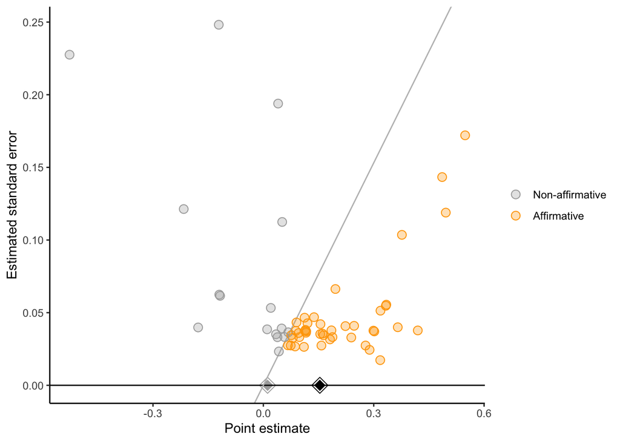

```r
## Source: Mathur & VanderWeele (2019)
## https://doi.org/10.31219/osf.io/s9dp6
## https://osf.io/prwyc/

## Worst-case sensitivity analysis with the clustering in studies
PublicationBias::svalue(yi = dat$g,
                        vi = dat$Var.g,
                        clustervar = dat$IDSTUDY,
                        q = 0, ## Threshold to shift to
                        model = "robust",
                        favor.positive = FALSE,  ## Not favoring positive effects
                        return.worst.meta = TRUE)


## Worst-case sensitivity analysis with the clustering in countries
PublicationBias::svalue(yi = dat$g,
                        vi = dat$Var.g,
                        clustervar = dat$IDCOUNTRY,
                        q = 0, ## Threshold to shift to
                        model = "robust",
                        favor.positive = FALSE,  ## Not favoring positive effects
                        return.worst.meta = TRUE)


## ?svalue
## From the description of the function in the R package documentation:
## Estimates the S-value, defined as the severity of publication bias
## (i.e., the ratio by which affirmative studies are more likely to be published ## than non-affirmative studies)
## that would be required to shift the pooled point ## estimate or its confidence interval limit to the value q.

## Significance funnel plot
PublicationBias::significance_funnel(yi = dat$g, vi = dat$Var.g)
```

## Moderation by publication year

```r
## Mixed-effects meta-regression model
CCREM.pub <- rma.mv(g,
                    Var.g,
                    random = list(~ 1 | IDSTUDY/ESID,
                                  ~ 1 | IDCOUNTRY),
                    method = "REML",
                    data = dat,
                    tdist = TRUE,
                    test = "t",
                    mods =~ scale(PubYear, ## mean-centered
                                  center = TRUE,
                                  scale = FALSE))

# Summarize the results
summary(CCREM.pub, digits=4)
```

```
##
## Multivariate Meta-Analysis Model (k = 59; method: REML)
##
##   logLik  Deviance       AIC       BIC      AICc
##  35.9444  -71.8888  -61.8888  -51.6735  -60.7123
##
## Variance Components:
##
##             estim    sqrt  nlvls  fixed        factor
## sigma^2.1  0.0250  0.1581     24     no       IDSTUDY
## sigma^2.2  0.0017  0.0413     59     no  IDSTUDY/ESID
## sigma^2.3  0.0053  0.0726     31     no     IDCOUNTRY
##
## Test for Residual Heterogeneity:
## QE(df = 57) = 470.8095, p-val < .0001
##
## Test of Moderators (coefficient 2):
## F(df1 = 1, df2 = 57) = 4.8943, p-val = 0.0310
##
## Model Results:
##
##                                               estimate      se    tval  df
## intrcpt                                         0.1448  0.0468  3.0961  57
## scale(PubYear, center = TRUE, scale = FALSE)    0.0296  0.0134  2.2123  57
##                                                 pval   ci.lb   ci.ub
## intrcpt                                       0.0030  0.0512  0.2385  **
## scale(PubYear, center = TRUE, scale = FALSE)  0.0310  0.0028  0.0564   *
##
## ---
## Signif. codes:  0 '***' 0.001 '**' 0.01 '*' 0.05 '.' 0.1 ' ' 1
```

```r
## Cluster-robust standard errors
robust(CCREM.pub, cluster = IDSTUDY, clubSandwich = FALSE)
```

```
##
## Multivariate Meta-Analysis Model (k = 59; method: REML)
##
## Variance Components:
##
##             estim    sqrt  nlvls  fixed        factor
## sigma^2.1  0.0250  0.1581     24     no       IDSTUDY
## sigma^2.2  0.0017  0.0413     59     no  IDSTUDY/ESID
## sigma^2.3  0.0053  0.0726     31     no     IDCOUNTRY
##
## Test for Residual Heterogeneity:
## QE(df = 57) = 470.8095, p-val < .0001
##
## Number of estimates:   59
## Number of clusters:    24
## Estimates per cluster: 1-21 (mean: 2.46, median: 1)
##
## Test of Moderators (coefficient 2):¹
## F(df1 = 1, df2 = 22) = 7.7149, p-val = 0.0110
##
## Model Results:
##
##                                               estimate      se¹    tval¹  df¹
## intrcpt                                         0.1448  0.0499   2.9012   22
## scale(PubYear, center = TRUE, scale = FALSE)    0.0296  0.0107   2.7776   22
##                                                 pval¹   ci.lb¹   ci.ub¹
## intrcpt                                       0.0083   0.0413   0.2484   **
## scale(PubYear, center = TRUE, scale = FALSE)  0.0110   0.0075   0.0517    *
##
## ---
## Signif. codes:  0 '***' 0.001 '**' 0.01 '*' 0.05 '.' 0.1 ' ' 1
##
## 1) results based on cluster-robust inference (var-cov estimator: CR1,
##    approx t/F-tests and confidence intervals, df: residual method)
```

```r
robust(CCREM.pub, cluster = IDCOUNTRY, clubSandwich = FALSE)
```

```
##
## Multivariate Meta-Analysis Model (k = 59; method: REML)
##
## Variance Components:
##
##             estim    sqrt  nlvls  fixed        factor
## sigma^2.1  0.0250  0.1581     24     no       IDSTUDY
## sigma^2.2  0.0017  0.0413     59     no  IDSTUDY/ESID
## sigma^2.3  0.0053  0.0726     31     no     IDCOUNTRY
##
## Test for Residual Heterogeneity:
## QE(df = 57) = 470.8095, p-val < .0001
##
## Number of estimates:   59
## Number of clusters:    31
## Estimates per cluster: 1-7 (mean: 1.90, median: 1)
##
## Test of Moderators (coefficient 2):¹
## F(df1 = 1, df2 = 29) = 14.6488, p-val = 0.0006
##
## Model Results:
##
##                                               estimate      se¹    tval¹  df¹
## intrcpt                                         0.1448  0.0282   5.1306   29
## scale(PubYear, center = TRUE, scale = FALSE)    0.0296  0.0077   3.8274   29
##                                                 pval¹   ci.lb¹   ci.ub¹
## intrcpt                                       <.0001   0.0871   0.2026   ***
## scale(PubYear, center = TRUE, scale = FALSE)  0.0006   0.0138   0.0455   ***
##
## ---
## Signif. codes:  0 '***' 0.001 '**' 0.01 '*' 0.05 '.' 0.1 ' ' 1
##
## 1) results based on cluster-robust inference (var-cov estimator: CR1,
##    approx t/F-tests and confidence intervals, df: residual method)
```

```r
## Variance explanation
## Level-specific R-squared as the proportional variance reduction

## Level: Primary studies
max(1-CCREM.pub$sigma2[1]/CCREM$sigma2[1] , 0)
```

```
## [1] 0.1876334
```

```r
## Level: Effect sizes
max(1-CCREM.pub$sigma2[2]/CCREM$sigma2[2] , 0)
```

```
## [1] 0
```

```r
## Level: Countries
max(1-CCREM.pub$sigma2[3]/CCREM$sigma2[3] , 0)
```

```
## [1] 0.04432089
```

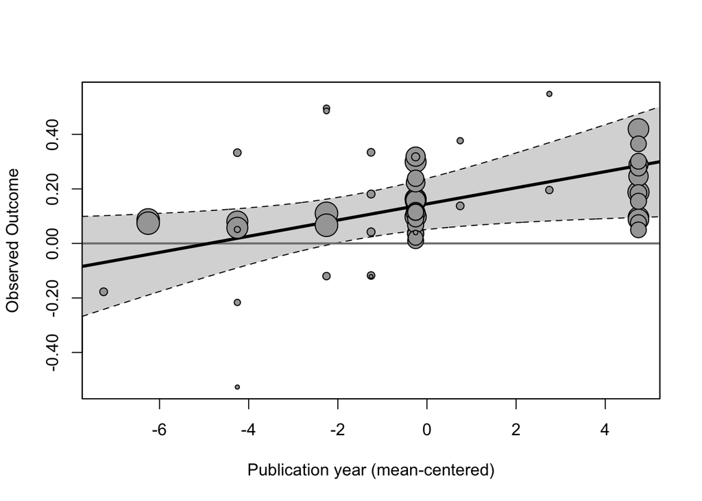

```r
## Regression plot
regplot(CCREM.pub,
        xlab = "Publication year (mean-centered)",
        refline = 0,
        digits = 2)
```

Publication year significantly and positively moderates the effect sizes. About 18.8$\%$ of the between-study variation is explained, and about 4.4$\%$ of the between-country variation is explained by publication year. Overall, larger effect sizes tend to be reported in more recent studies.

## Influential effect sizes

We can further identify influential effect sizes at several levels of analysis.

### Level: Effect sizes

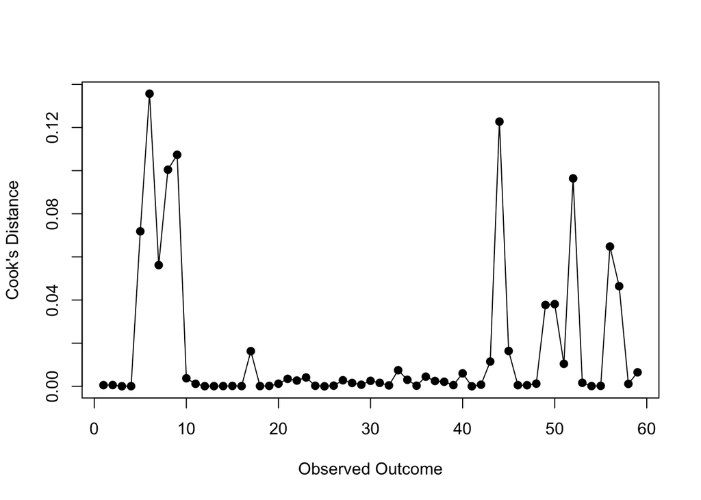

```r
## Source: https://wviechtb.github.io/metafor/reference/influence.rma.mv.html
## Compute Cook's distances
CCREM.cook1 <- metafor::cooks.distance.rma.mv(CCREM,
                                              reestimate = FALSE,
                                              parallel = "multicore",
                                              ncpus = ncores - 1)

## Plot the D values
plot(CCREM.cook1,
     type="o",
     pch=19,
     xlab="Observed Outcome",
     ylab="Cook's Distance")
```

### Level: Studies

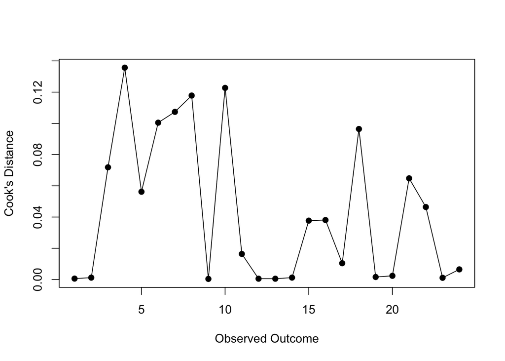

```r
## Source: https://wviechtb.github.io/metafor/reference/influence.rma.mv.html
## Compute Cook's distances
CCREM.cook2 <- metafor::cooks.distance.rma.mv(CCREM,
                                              reestimate = FALSE,
                                              parallel = "multicore",
                                              ncpus = ncores - 1,
                                              cluster = IDSTUDY)

## Plot the D values
plot(CCREM.cook2,
     type="o",
     pch=19,
     xlab="Observed Outcome",
     ylab="Cook's Distance")
```

### Level: Countries

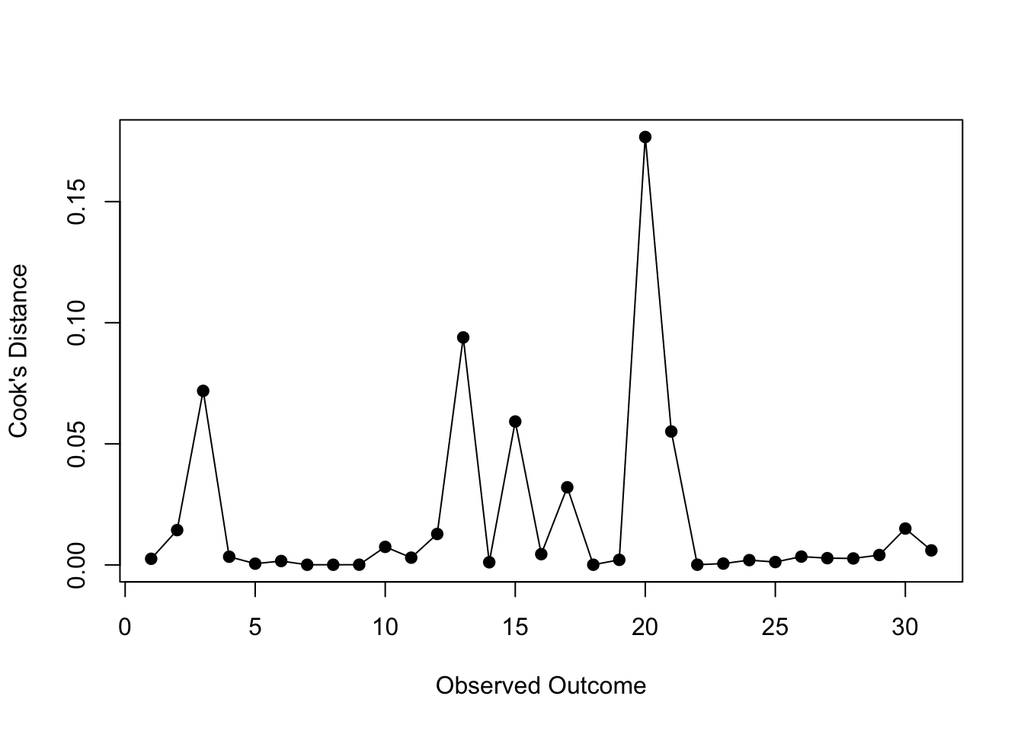

```r
## Source: https://wviechtb.github.io/metafor/reference/influence.rma.mv.html
## Compute Cook's distances
CCREM.cook3 <- metafor::cooks.distance.rma.mv(CCREM,
                                              reestimate = FALSE,
                                              parallel = "multicore",
                                              ncpus = ncores - 1,
                                              cluster = IDCOUNTRY)

## Plot the D values
plot(CCREM.cook3,
     type="o",
     pch=19,
     xlab="Observed Outcome",
     ylab="Cook's Distance")
```

In subsequent steps, these influential effect sizes could be excluded from the meta-analytic data to see how sensitive the overall effect size and the heterogeneity estimates are to their inclusion/exclusion. This calls for sensitivity analyses.